# ps05

2023-11-19

## 1.1

```r
library(tidyverse)
```

```r
library(ggplot2)
library(nycflights13)

flights %>%
  sample_n(5)
```

```
## # A tibble: 5 × 19
##    year month   day dep_time sched_dep_time dep_delay arr_time sched_arr_time
##   <int> <int> <int>    <int>          <int>     <dbl>    <int>          <int>
## 1  2013     4    11     1458           1422        36     1810           1656
## 2  2013     3    10     1431           1435        -4     1621           1630
## 3  2013    10     6      901            859         2     1200           1153
## 4  2013    10     7      741            749        -8     1112           1043
## 5  2013     3    29     2038           2000        38     2317           2259
## # ℹ 11 more variables: arr_delay <dbl>, carrier <chr>, flight <int>,
## #   tailnum <chr>, origin <chr>, dest <chr>, air_time <dbl>, distance <dbl>,
## #   hour <dbl>, minute <dbl>, time_hour <dttm>
```

## 1.1.2.a

```r
print(sum(!(nchar(flights$origin) == 3 & nchar(flights$dest) == 3)))
```

```
## [1] 0
```

check if there are airport codes that are not 3 characters long

## 1.1.2.b

```r
print(sum(grepl("\\d", flights$origin) & grepl("\\d", flights$dest)))
```

```
## [1] 0
```

check if there are airport codes that contains digits

## 1.1.3

```r
summary(flights$arr_delay)
```

```
##     Min.  1st Qu.   Median     Mean  3rd Qu.     Max.     NA's
##  -86.000  -17.000   -5.000    6.895   14.000 1272.000     9430
```

There are 9430 missing arrival delay in data. It is a problem because if we want to analyze delay time, missing a relatively large portion of arrival delay might result in bias of the result

## 1.1.4

based on the summary from above, the max delay is approximately 21 hours, which is plausible because airport has certain compensation for long time delay like that. It’s also possible to have about one and a half hour early

## 1.1.5

```r
flights %>%
  select(arr_delay, dest) %>%
  group_by(dest) %>%
  summarize(average_delay = mean(arr_delay, na.rm = TRUE)) %>%
  arrange(desc(average_delay)) %>%
  head(3)
```

```
## # A tibble: 3 × 2
##   dest  average_delay
##   <chr>         <dbl>
## 1 CAE            41.8
## 2 TUL            33.7
## 3 OKC            30.6
```

## 1.1.6

```r
month_delay <- flights %>%
  select(arr_delay, month) %>%
  group_by(month) %>%
  summarize(average_delay = mean(arr_delay, na.rm = TRUE))
head(month_delay, 12)
```

```
## # A tibble: 12 × 2
##    month average_delay
##    <int>         <dbl>
##  1     1         6.13
##  2     2         5.61
##  3     3         5.81
##  4     4        11.2
##  5     5         3.52
##  6     6        16.5
##  7     7        16.7
##  8     8         6.04
##  9     9        -4.02
## 10    10        -0.167
## 11    11         0.461
## 12    12        14.9
```

## 1.1.7

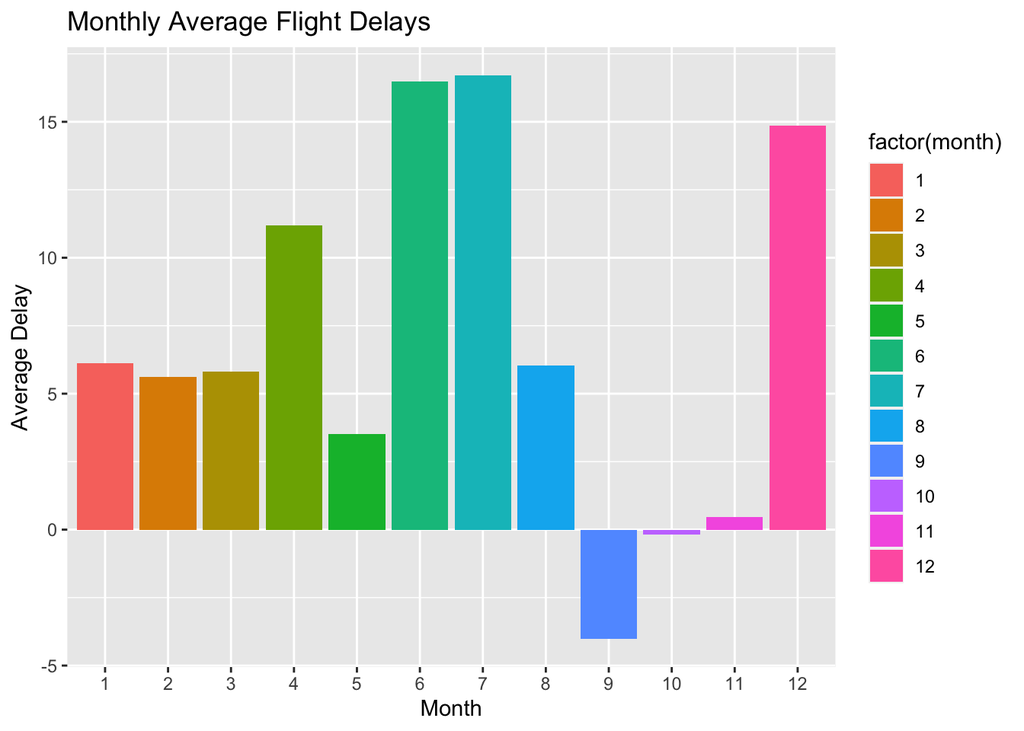

```r
ggplot(month_delay, aes(x = factor(month), y = average_delay)) +
  geom_bar(stat = "identity", aes(fill = factor(month))) +
  labs(x = "Month", y = "Average Delay", title = "Monthly Average Flight Delays")
```

There’s not a clear pattern here, but from Septermbet to November, it experience a really low delay even arrive early. There’s a relatively high delay during June, July, and December. It’s probably due to holidays and increasing number of flights.

## 1.1.8

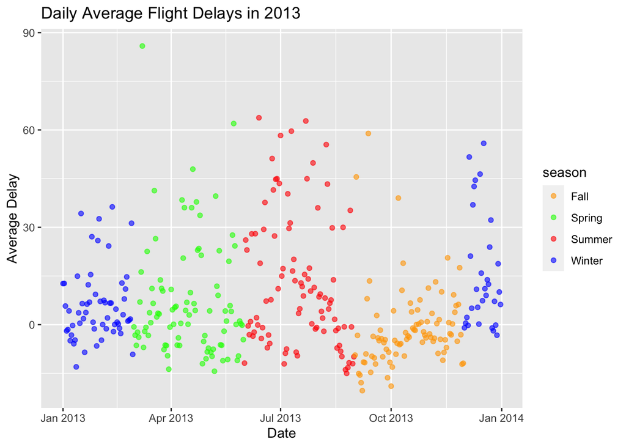

```r
daily_delay <- flights %>%
  filter(year == 2013) %>%
  mutate(date = make_date(year, month, day),
         season = case_when(
           month %in% c(12, 1, 2) ~ "Winter",
           month %in% 3:5 ~ "Spring",
           month %in% 6:8 ~ "Summer",
           month %in% 9:11 ~ "Fall"
         )) %>%
  group_by(date, season) %>%
  summarize(average_delay = mean(arr_delay, na.rm = TRUE), .groups = 'drop')

ggplot(daily_delay, aes(x = date, y = average_delay, color = season)) +
  geom_point(alpha = 0.6) +
  scale_color_manual(values = c("Winter" = "blue", "Spring" = "green", "Summer" = "red", "Fall" = "orange")) +
  labs(x = "Date", y = "Average Delay", title = "Daily Average Flight Delays in 2013")
```

the delay is more common in summer compares to winter and the delay is more common in spring compare to fall

## 1.2.1

```r
chicago <- flights %>%
  filter(dest == "ORD")
nrow(chicago)
```

```
## [1] 17283
```

there are 17283 flights to chicago

## 1.2.2

```r
chicago %>%
  arrange(air_time) %>%
  select(year, month, day, dep_time, air_time, carrier, origin) %>%
  slice(1)
```

```
## # A tibble: 1 × 7
##    year month   day dep_time air_time carrier origin
##   <int> <int> <int>    <int>    <dbl> <chr>   <chr>
## 1  2013     8    21     1604       87 UA      EWR
```

the fastest flight to chicago is 87 minutes from Newark Liberty International Airport by United Airline on 2013/08/21 at 16:04

## 1.2.3

The typical flight times for direct flights from NYC to ORD is 160 minutes, the data is only half of it do it doesn’t seems to be realistic.

## 1.2.4

```r
chicago %>%
  arrange(desc(air_time)) %>%
  select(year, month, day, dep_time, air_time, carrier, origin) %>%
  slice(1)
```

```
## # A tibble: 1 × 7
##    year month   day dep_time air_time carrier origin
##   <int> <int> <int>    <int>    <dbl> <chr>   <chr>
## 1  2013     4    10      638      198 UA      EWR
```

## 1.2.5

```r
chicago %>%
  mutate(speed_mph = distance / (air_time / 60)) %>%
  filter(!is.na(speed_mph)) %>%
  arrange(speed_mph) %>%
  select(time_hour, carrier, dep_delay, speed = speed_mph) %>%
  slice(c(1:3, (n()-2):n()))
```

```
## # A tibble: 6 × 4
##   time_hour           carrier dep_delay speed
##   <dttm>              <chr>       <dbl> <dbl>
## 1 2013-04-10 06:00:00 UA             -2  218.
## 2 2013-09-19 07:00:00 UA             -4  229.
## 3 2013-09-19 07:00:00 UA              1  229.
## 4 2013-05-08 13:00:00 MQ              1  469.
## 5 2013-07-12 18:00:00 MQ             38  469.
## 6 2013-08-21 15:00:00 UA              9  496.
```

## 1.2.6

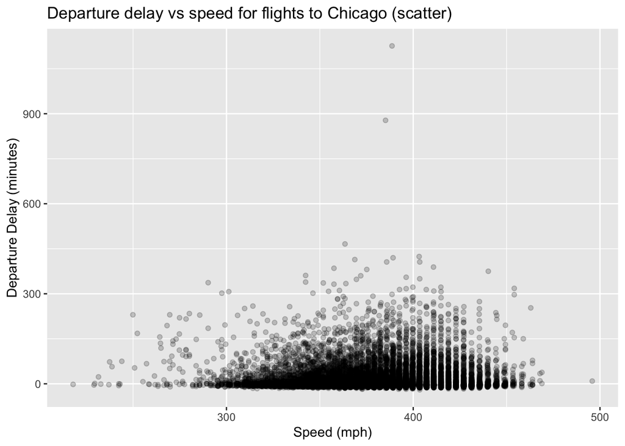

```r
chicago %>%
  mutate(speed_mph = distance / (air_time / 60)) %>%
  filter(!is.na(speed_mph) & !is.na(air_time)) %>%
  ggplot(aes(y = dep_delay, x = speed_mph)) +
  geom_point(alpha = 0.2) +
  labs(x = "Speed (mph)", y = "Departure Delay (minutes)",
       title = "Departure delay vs speed for flights to Chicago (scatter)")
```

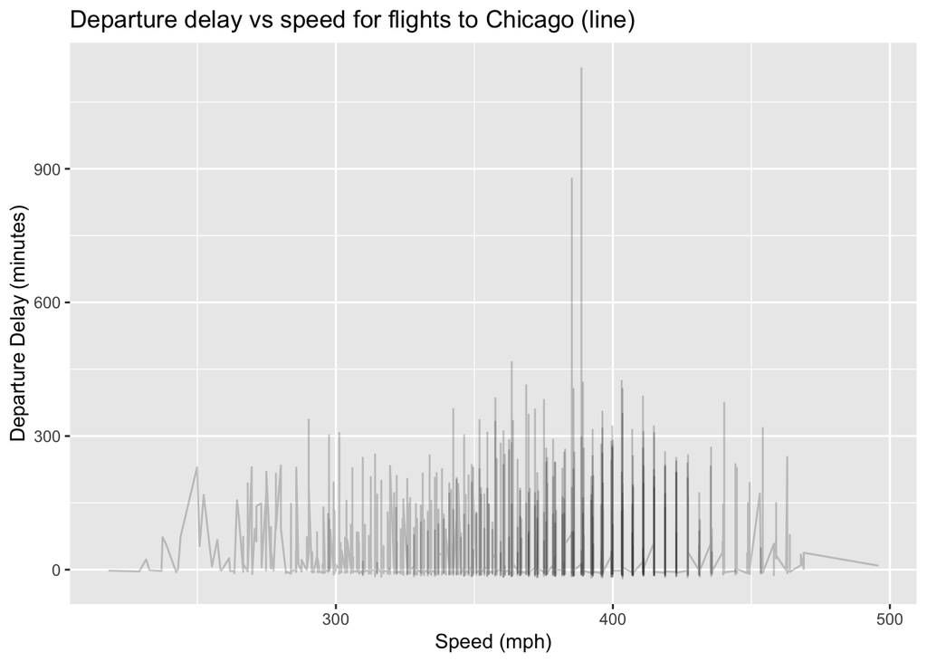

```r
chicago %>%
  mutate(speed_mph = distance / (air_time / 60)) %>%
  filter(!is.na(speed_mph) & !is.na(air_time)) %>%
  ggplot(aes(y = dep_delay, x = speed_mph)) +
  geom_line(alpha = 0.2) +
  labs(x = "Speed (mph)", y = "Departure Delay (minutes)",
       title = "Departure delay vs speed for flights to Chicago (line)")
```

## 2.1.1

```r
gm <- read_delim("../Data/gapminder.csv.bz2")
dim(gm)
```

```
## [1] 13055    25
```

we have 25 columns and 13055 rows

## 2.1.2

```r
gm %>%
  sample_n(5)
```

```
## # A tibble: 5 × 25
##   iso3  name       iso2  region   `sub-region`       `intermediate-region`  time
##   <chr> <chr>      <chr> <chr>    <chr>              <chr>                 <dbl>
## 1 SVN   Slovenia   SI    Europe   Southern Europe    <NA>                   1979
## 2 AZE   Azerbaijan AZ    Asia     Western Asia       <NA>                   2019
## 3 URY   Uruguay    UY    Americas Latin America and… South America          1997
## 4 DZA   Algeria    DZ    Africa   Northern Africa    <NA>                   2003
## 5 DMA   Dominica   DM    Americas Latin America and… Caribbean              1973
## # ℹ 18 more variables: totalPopulation <dbl>, fertilityRate <dbl>,
## #   lifeExpectancy <dbl>, childMortality <dbl>, youthFemaleLiteracy <dbl>,
## #   youthMaleLiteracy <dbl>, adultLiteracy <dbl>, GDP_PC <dbl>,
## #   accessElectricity <dbl>, agriculturalLand <dbl>, agricultureTractors <dbl>,
## #   cerealProduction <dbl>, fertilizerHa <dbl>, co2 <dbl>,
## #   greenhouseGases <dbl>, co2_PC <dbl>, pm2.5_35 <dbl>, battleDeaths <dbl>
```

It looks ok because it contains all the varibales we want. It contains some NA values.

## 2.1.3

```r
gm %>%
  distinct(iso3) %>%
  nrow()
```

```
## [1] 253
```

```r
gm %>%
  distinct(iso2) %>%
  nrow()
```

```
## [1] 249
```

```r
gm %>%
  distinct(name) %>%
  nrow()
```

```
## [1] 250
```

there are 253 countries based on iso3, 249 countries based on iso2, 250 countries based on name

## 2.1.4.a

```r
gm %>%
  group_by(iso2) %>%
  summarize(unique_names = n_distinct(name)) %>%
  filter(unique_names > 1) %>%
  head()
```

```
## # A tibble: 1 × 2
##   iso2  unique_names
##   <chr>        <int>
## 1 <NA>             2
```

```r
gm %>%
  filter(is.na(iso2)) %>%
  distinct(name)
```

```
## # A tibble: 2 × 1
##   name
##   <chr>
## 1 <NA>
## 2 Namibia
```

A country with missing name and Namibia has a missing iso2

## 2.1.4.b

```r
gm %>%
  group_by(name) %>%
  summarize(unique_iso3 = n_distinct(iso3), .groups = 'drop') %>%
  filter(unique_iso3 > 1) %>%
  head()
```

```
## # A tibble: 1 × 2
##   name  unique_iso3
##   <chr>       <int>
## 1 <NA>            4
```

```r
gm %>%
  filter(is.na(name)) %>%
  distinct(iso3)
```

```
## # A tibble: 4 × 1
##   iso3
##   <chr>
## 1 CHANISL
## 2 GBM
## 3 KOS
## 4 NLD_CURACAO
```

Country has mroe than one iso3 code are CHANISL, GBM, KOS, NLD CURACAO

## 2.2.1

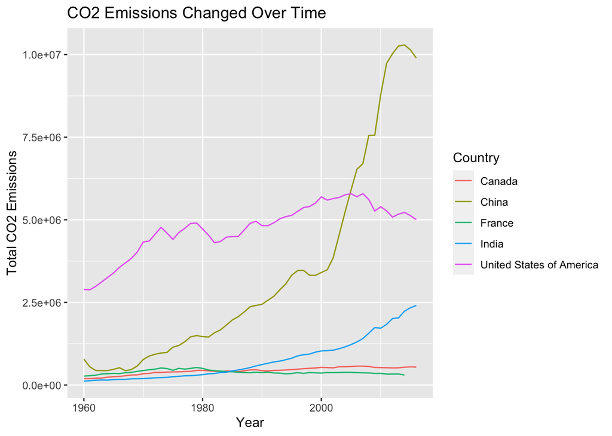

```r
selected <- c("United States of America", "China", "India", "Canada", "France")
selected_gm <- gm %>%
  filter(name %in% selected  & !is.na(co2))

ggplot(selected_gm, aes(x = time, y = co2, color = name)) +
  geom_line() +
  labs(title = "CO2 Emissions Changed Over Time",
       x = "Year",
       y = "Total CO2 Emissions",
       color = "Country")
```

China has significantly more CO2 emission over 2005 compares to other counties, Canada and France keep a low CO2 emission

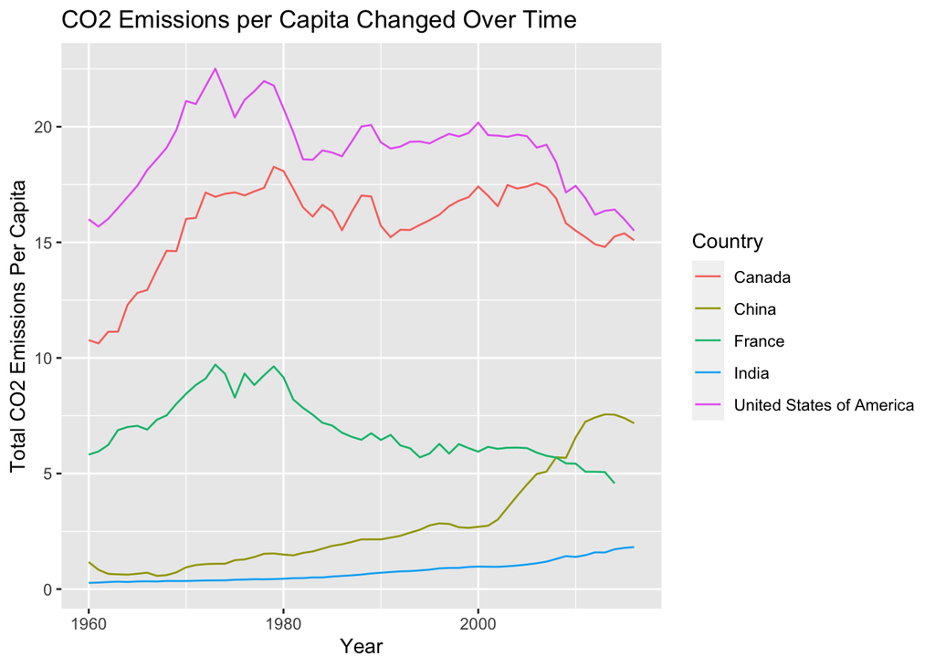

```r
ggplot(selected_gm, aes(x = time, y = co2_PC, color = name)) +
  geom_line() +
  labs(title = "CO2 Emissions per Capita Changed Over Time",
       x = "Year",
       y = "Total CO2 Emissions Per Capita",
       color = "Country")
```

The figure suggests that US has a highest CO2 Emmisions per Capita and India has the lowest CO2 Emmisions per Capita

## 2.2.3

```r
avg_continent <- gm %>%
  filter(!is.na(region)) %>%
  group_by(region, time) %>%
  summarize(average_CO2_per_capita = mean(co2_PC, na.rm = TRUE))
head(avg_continent)
```

```
## # A tibble: 6 × 3
## # Groups:   region [1]
##   region  time average_CO2_per_capita
##   <chr>  <dbl>                  <dbl>
## 1 Africa  1960                  0.291
## 2 Africa  1961                  0.300
## 3 Africa  1962                  0.299
## 4 Africa  1963                  0.310
## 5 Africa  1964                  0.349
## 6 Africa  1965                  0.385
```

## 2.2.4

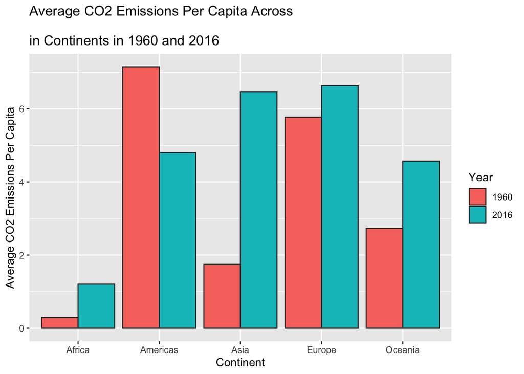

```r
avg_continent %>%
  filter(time %in% c(1960, 2016)) %>%
  ggplot(aes(x = region, y = average_CO2_per_capita, fill = as.factor(time))) +
  geom_bar(stat = "identity",
           position = position_dodge(),
           color = "gray20") +
  labs(title = "Average CO2 Emissions Per Capita Across
       \nin Continents in 1960 and 2016",
       x = "Continent",
       y = "Average CO2 Emissions Per Capita",
       fill = "Year")
```

## 2.3.1

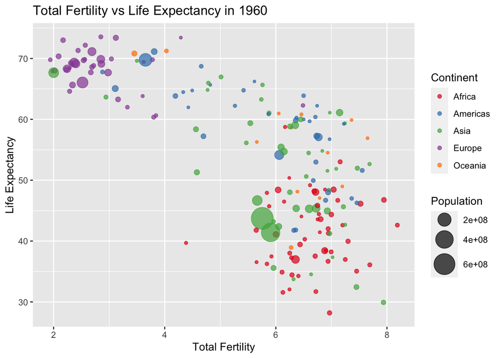

```r
letf1960 <- gm %>%
  filter(time == 1960 &
           !is.na(fertilityRate) &
           !is.na(lifeExpectancy)&
           !is.na(region))

ggplot(letf1960, aes(x = fertilityRate,
           y = lifeExpectancy,
           size = totalPopulation,
           color = region)) +
  geom_point(alpha = 0.7) +
  scale_size(range = c(1, 10), name = "Population") +
  scale_color_brewer(palette = "Set1") +
  labs(title = "Total Fertility vs Life Expectancy in 1960",
       x = "Total Fertility",
       y = "Life Expectancy",
       color = "Continent")
```

total fertility and life expectancy is generally inversely proportional Europe has overall lowet fertility and highest life expectancy Africa has overall highest fertility and lowest life expectancy